# Forecasting

## Calendar Adjustment

The number of days per month are different so monthly numbers could be affected by them.

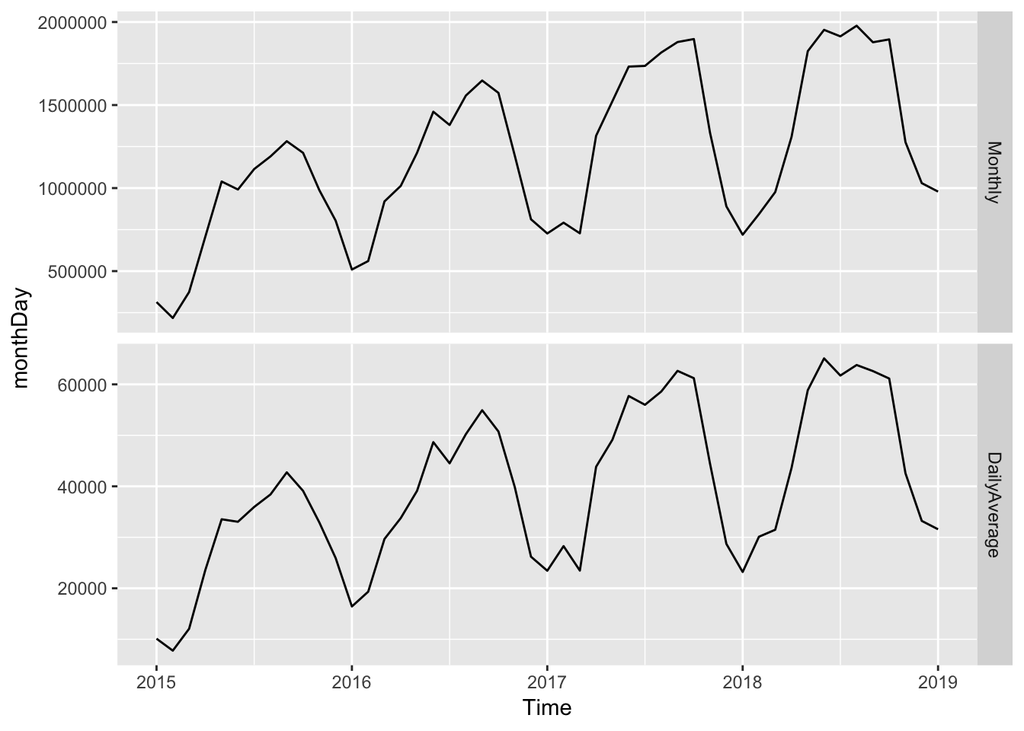

```r
monthDay <- cbind(Monthly = cbMonth, DailyAverage = cbMonth/monthdays(cbMonth))

autoplot(monthDay, facet = TRUE)
```

Other Adjustments to consider:

- Adjusting for inflation (using Consumer Price Index)
- log transformations (useful for monetary variables)
- power transformations (you can use square roots or cube roots)

# Box-Cox Transformation

This transformation utilizes both logarithm and power transformation with a parameter called $\lambda$.

$$w_t =
\begin{cases}
\\log(y_t), &\text{if } \lambda = 0 \\
\dfrac{y_i^\lambda-1}{\lambda}, &\text{otherwise. }
\end{cases}$$

you can see that if $\lambda = 0$ then the natural log is used, but if $\lambda \neq 0$ the power transformation is used. One more thing of note is that if $\lambda = 1$ then $w_t = y_t -1$ which means the data will be shifted down.

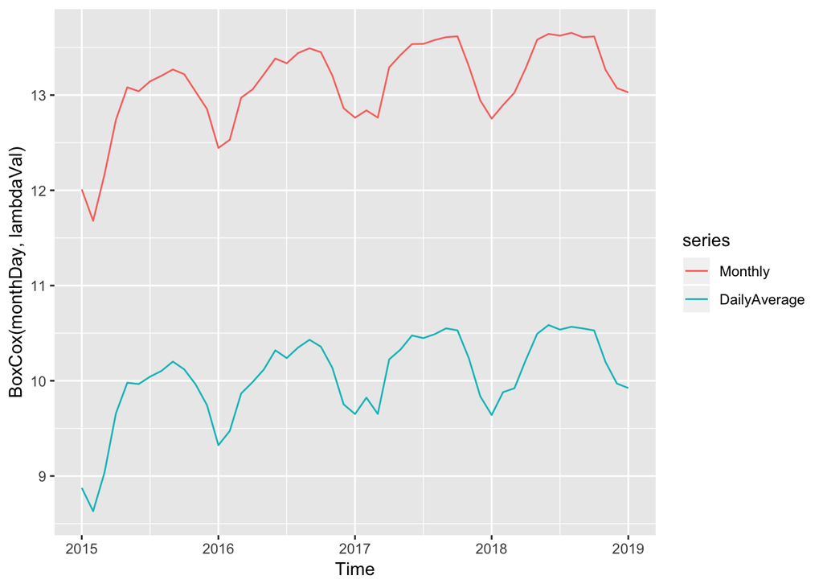

```r
lambdaVal <- BoxCox.lambda(monthDay)
autoplot(BoxCox(monthDay, lambdaVal))
```

## Bias Adjustment

When we get the back-transformed forecast from the Box-Cox transofmation, it will return the median of the forecast distribution rather than the mean. The difference between the mean and the median is called the **bias** hence **bias-adjusted** point forecasts.

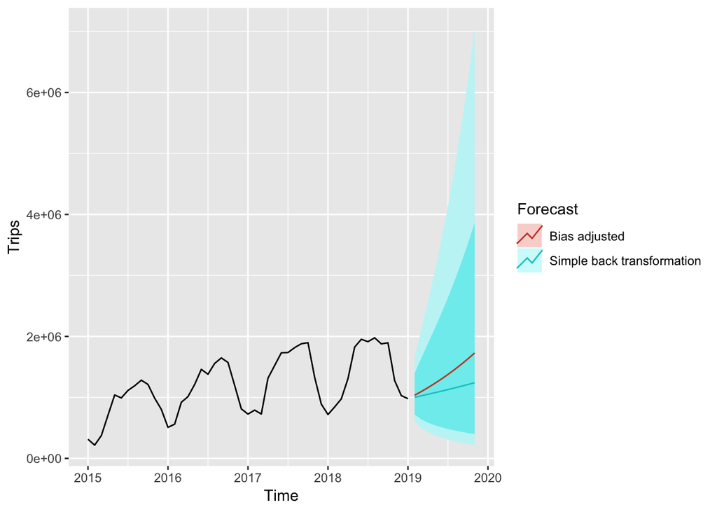

```r
fc <- rwf(monthDay[,"Monthly"], drift=TRUE, lambda=0)
fc2 <- rwf(monthDay[,"Monthly"], drift=TRUE, lambda=0, biasadj=TRUE)
autoplot(monthDay[,"Monthly"]) +
  autolayer(fc, series="Simple back transformation") +
  autolayer(fc2, series="Bias adjusted", PI=FALSE) +
  guides(colour=guide_legend(title="Forecast")) + ylab("Trips")
```

## ETS

There are 15 different kinds of exponential smoothing algorithms

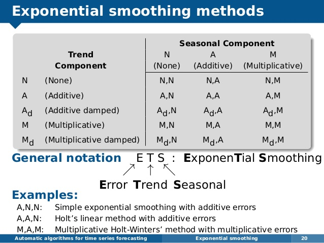

### Simple exponential smoothing

if we consider the naive method…
$$\hat y_{T+h|T} = y_T$$
the last observed value will be our forecast.

If we consider the avereage method…
$$\hat y_{T+h|T} = \frac{1}{T} \sum_{t=1}^T y_t$$
all observations are equally weighted.

To get something in between these extremes exponential smoothing can be employed…
$$\hat y_{T+1|T} = \alpha y_T + \alpha(1-\alpha) y_{T-1}+ \alpha(1-\alpha)^2 y_{T-2} + ...$$
We add a new variable called $\apha$ which is going to be $0 \leq \alpha \leq 1$. You can see the most recent variable is $\alpha y_T$ getting the full weight, while the next one is $\alpha(1-\alpha) y_{T-1}$ getting multiplied by itself, the next one is a square, the next one after that would be a cube and you’ll see that the older and older values from our timeseries will be weighted less.

An alternative representation is the component form. We only have 1 component for smoothing, later we will look at seasonality and trend.

We can think of the component as a level, and the algorithm “learns” the new level from the data. you have to initialize $l_1$ with some value and often it can be the first value.

```r
oildata <- window(fpp2::oil, start=1996)
fc <- forecast::ses(oildata, h = 5)
round(forecast::accuracy(fc), 2)
```

```
##               ME  RMSE   MAE MPE MAPE MASE  ACF1
## Training set 6.4 28.12 22.26 1.1 4.61 0.93 -0.03
```